# CRIM 515 Final Project In-Class

09 December 2024

- 1. Research Question
- 2. Literature Review
- 3. Data
  - Libraries

Some R Markdown styles to try, if you’re interested:

# 1. Research Question

# 2. Literature Review

# 3. Data

### Libraries

```r
library(tidyverse)
library(leaflet)
library(sf)
library(tigris)
library(zoo)
library(aTSA)
library(tseries)
library(forecast)
```

Get the latest Fairfax calls for service data:

```r
calls.full <- read.csv(sprintf("https://docs.google.com/uc?id=%s&export=download",
                               "1ti7BCMe1vvDVVr75p6lqvgouCy_ae7rn"))
```

Format the date and add month columns:

```r
calls.full$DATE <- as.Date(calls.full$date, format = "%Y-%m-%d")
calls.full$MONTHS <- months(calls.full$DATE)
calls.full$MONTH <- month(calls.full$DATE)
```

Determine the total count and percentage of each call type:

```r
sum.calls <- calls.full %>%
  group_by(type) %>%
  summarise(call.count = n()) %>%
  mutate(pct = round(call.count/sum(call.count)*100,2))
```

Identify a set of calls to analyze, and then filter the data:

```r
group <- c("ANIMAL BITE", "ANIMAL CASE", "ANIMAL CONTROL", "ANIMAL LOST-FOUND")
calls.subset <- calls.full %>% filter(calls.full$type %in% group)
```

Calculate calls per day:

```r
calls <- calls.subset %>%
  group_by(DATE) %>%
  summarise(CALL.COUNT = n())
```

Fill in blank days:

```r
calls <- calls %>%
  complete(DATE = seq.Date(min(DATE), max(DATE), by = "day")) %>%
  mutate(WEEKDAY = lubridate::wday(DATE, label = T, week_start = 1),
         MONTH = lubridate::month(DATE, label = T, abbr = F),
         WEEK = isoweek(DATE),
         DAY = day(DATE),
         YEAR = year(DATE))
calls <- replace(calls, is.na(calls), 0)
```

Make the data a time series:

```r
cleaned.calls <- zoo(calls$CALL.COUNT,
                       seq(from = as.Date(min(calls$DATE)),
                           to = as.Date(max(calls$DATE)), by = 1))
```

Generate basic stats and a basic graph:

```r
summary(cleaned.calls)
```

```
##      Index            cleaned.calls
##  Min.   :2007-01-03   Min.   : 0.000
##  1st Qu.:2011-06-18   1st Qu.: 1.000
##  Median :2015-12-02   Median : 1.000
##  Mean   :2015-12-02   Mean   : 1.655
##  3rd Qu.:2020-05-17   3rd Qu.: 2.000
##  Max.   :2024-10-31   Max.   :11.000
```

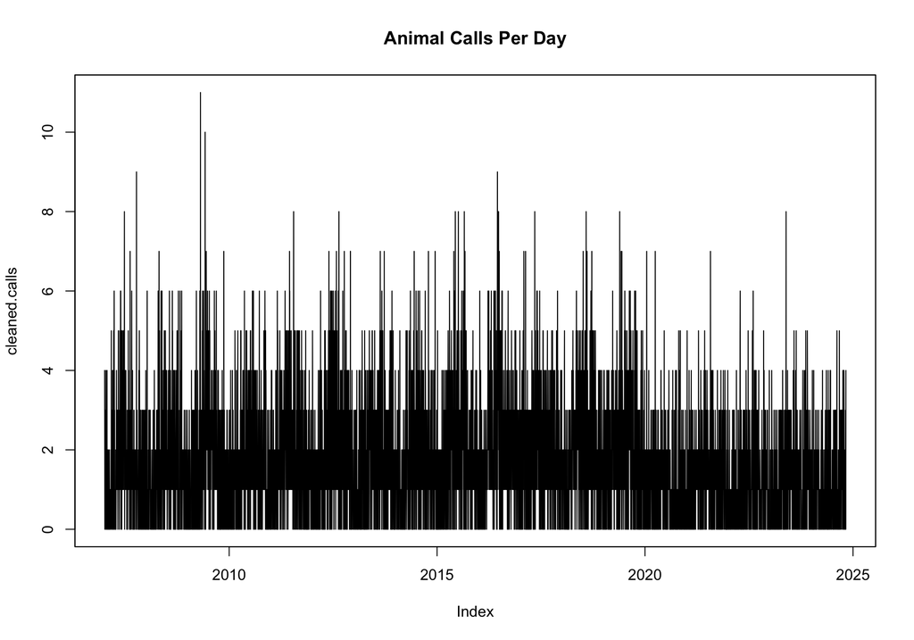

```r
plot(cleaned.calls)
title("Animal Calls Per Day")
```

Make the data stationary:

```r
stationary1 <- diff(cleaned.calls, differences = 1)
stationary2 <- diff(cleaned.calls, differences = 2)
stationary3 <- diff(cleaned.calls, differences = 3)
```

Plot each one:

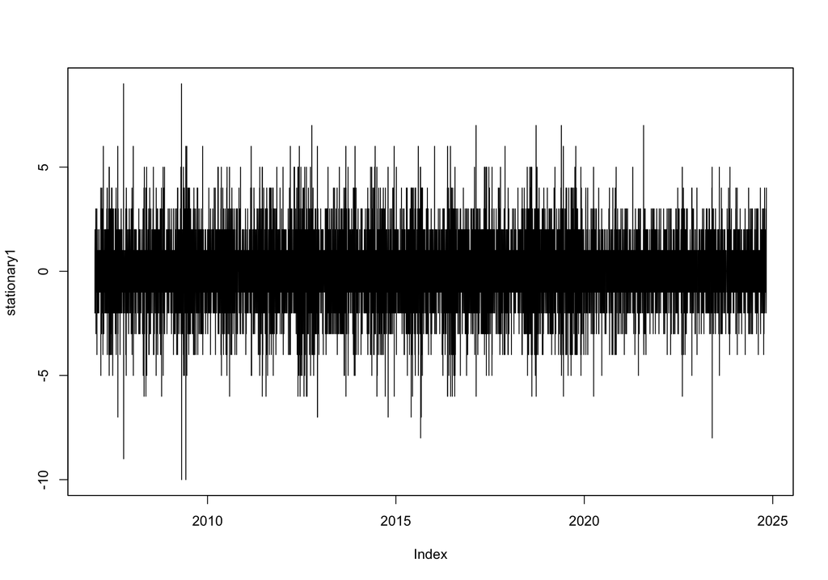

```r
plot(stationary1)
```

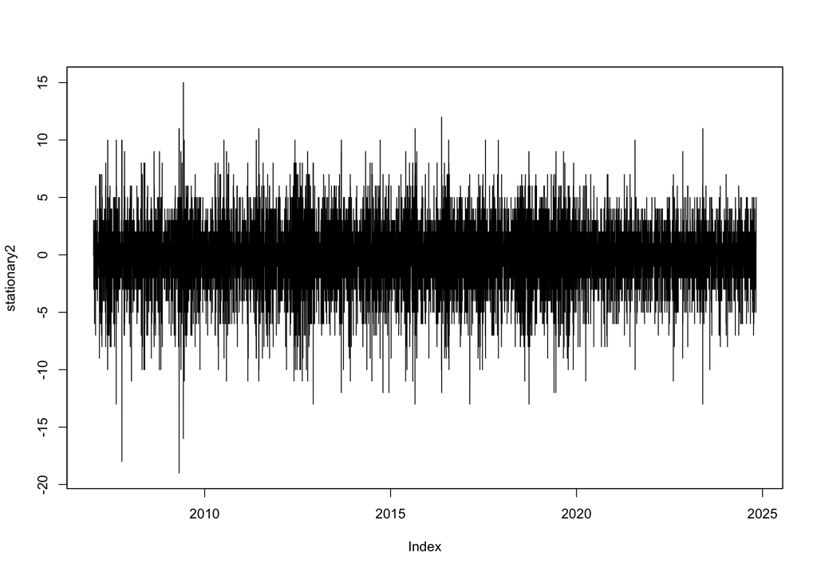

```r
plot(stationary2)
```

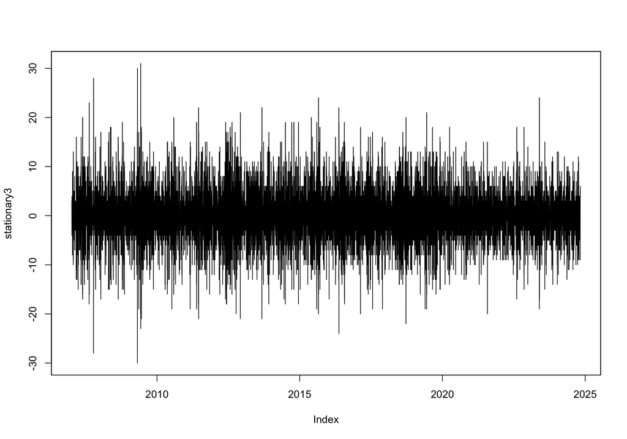

```r
plot(stationary3)
```

Run ADF tests on the original data, and the stationary datasets:

```r
adf.test(as.matrix(cleaned.calls))
```

```
##
##  Augmented Dickey-Fuller Test
##
## data:  as.matrix(cleaned.calls)
## Dickey-Fuller = -11.696, Lag order = 18, p-value = 0.01
## alternative hypothesis: stationary
```

```r
adf.test(as.matrix(stationary1))
```

```
##
##  Augmented Dickey-Fuller Test
##
## data:  as.matrix(stationary1)
## Dickey-Fuller = -30.635, Lag order = 18, p-value = 0.01
## alternative hypothesis: stationary
```

```r
adf.test(as.matrix(stationary2))
```

```
##
##  Augmented Dickey-Fuller Test
##
## data:  as.matrix(stationary2)
## Dickey-Fuller = -39.332, Lag order = 18, p-value = 0.01
## alternative hypothesis: stationary
```

```r
adf.test(as.matrix(stationary3))
```

```
##
##  Augmented Dickey-Fuller Test
##
## data:  as.matrix(stationary3)
## Dickey-Fuller = -48.614, Lag order = 18, p-value = 0.01
## alternative hypothesis: stationary
```

Stationary1 is the winner.

Determine the p value using PACF:

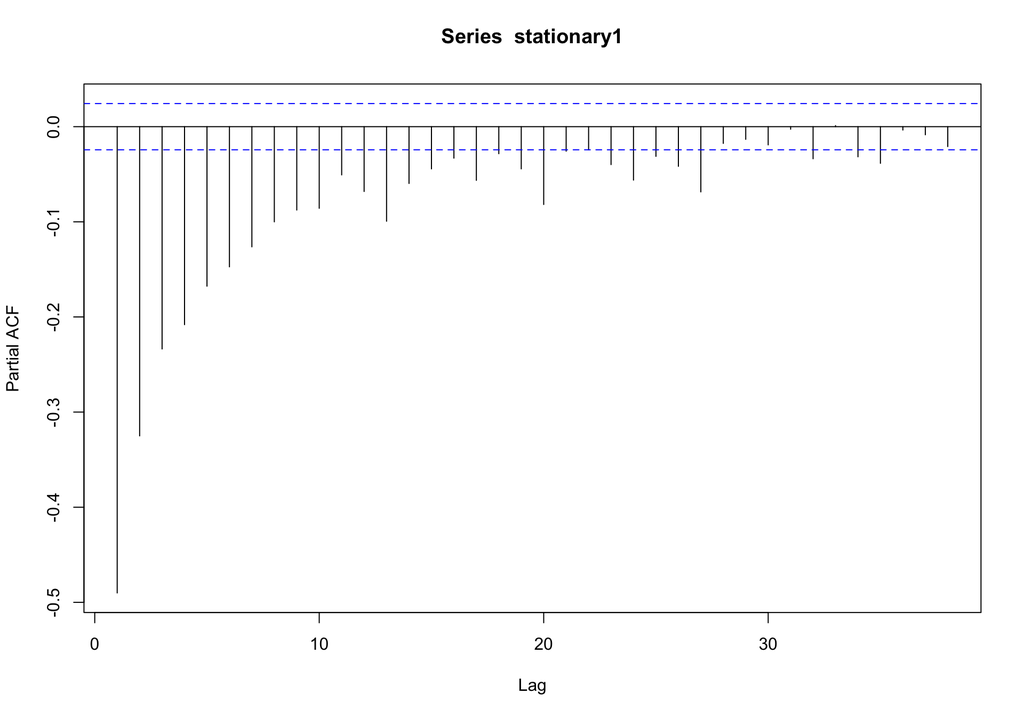

```r
pacf(stationary1)
```

```r
pacf(stationary1, pl=FALSE)
```

```
##
## Partial autocorrelations of series 'stationary1', by lag
##
##      1      2      3      4      5      6      7      8      9     10     11
## -0.490 -0.325 -0.234 -0.208 -0.168 -0.147 -0.126 -0.100 -0.088 -0.086 -0.051
##     12     13     14     15     16     17     18     19     20     21     22
## -0.068 -0.099 -0.060 -0.044 -0.033 -0.056 -0.028 -0.044 -0.082 -0.026 -0.024
##     23     24     25     26     27     28     29     30     31     32     33
## -0.040 -0.056 -0.031 -0.042 -0.069 -0.018 -0.013 -0.019 -0.003 -0.034  0.001
##     34     35     36     37     38
## -0.032 -0.039 -0.004 -0.009 -0.021
```

The p value for this example will be 13.

Determine the q value using ACF:

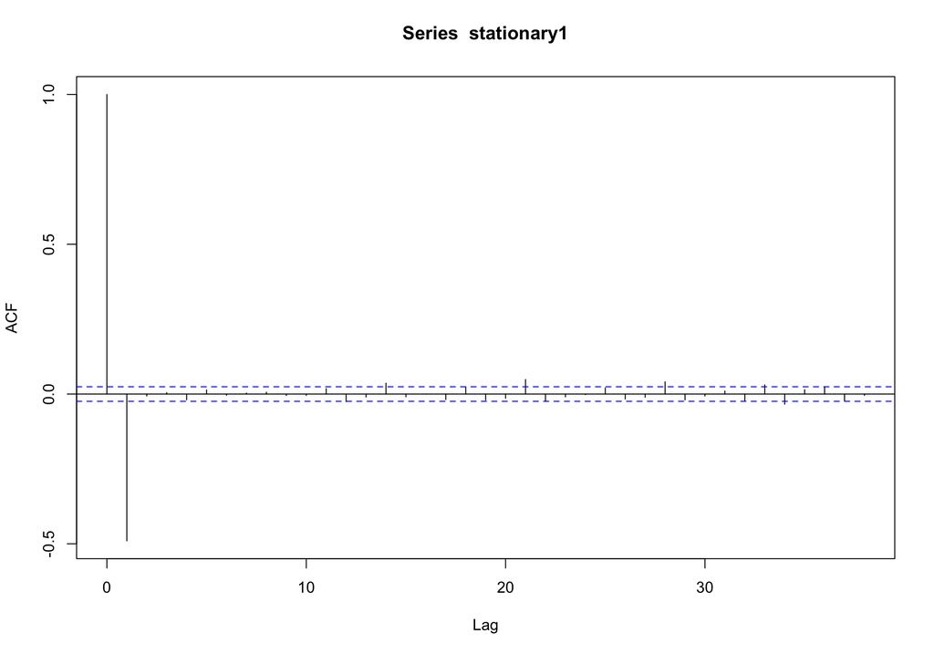

```r
acf(stationary1)
```

```r
acf(stationary1, pl=FALSE)
```

```
##
## Autocorrelations of series 'stationary1', by lag
##
##      0      1      2      3      4      5      6      7      8      9     10
##  1.000 -0.490 -0.007  0.005 -0.020  0.014 -0.005  0.003  0.006 -0.005 -0.005
##     11     12     13     14     15     16     17     18     19     20     21
##  0.018 -0.026 -0.010  0.036 -0.009  0.000 -0.018  0.024 -0.020 -0.014  0.048
##     22     23     24     25     26     27     28     29     30     31     32
## -0.024 -0.010 -0.002  0.020 -0.017 -0.011  0.041 -0.020 -0.007  0.010 -0.022
##     33     34     35     36     37     38
##  0.031 -0.034  0.014  0.024 -0.023 -0.005
```

The q value for this example will be 1.

Build the ARIMA model:

```r
arima.calls <- auto.arima(cleaned.calls, d = 1, max.p = 13, max.q = 1, seasonal = T)
summary(arima.calls)
```

```
## Series: cleaned.calls
## ARIMA(1,1,1)
##
## Coefficients:
##          ar1      ma1
##       0.0200  -0.9624
## s.e.  0.0129   0.0034
##
## sigma^2 = 2.042:  log likelihood = -11563.73
## AIC=23133.45   AICc=23133.46   BIC=23153.8
##
## Training set error measures:
##                        ME     RMSE      MAE  MPE MAPE      MASE         ACF1
## Training set -0.001690847 1.428774 1.119778 -Inf  Inf 0.7610518 0.0002094817
```

Check the model residuals:

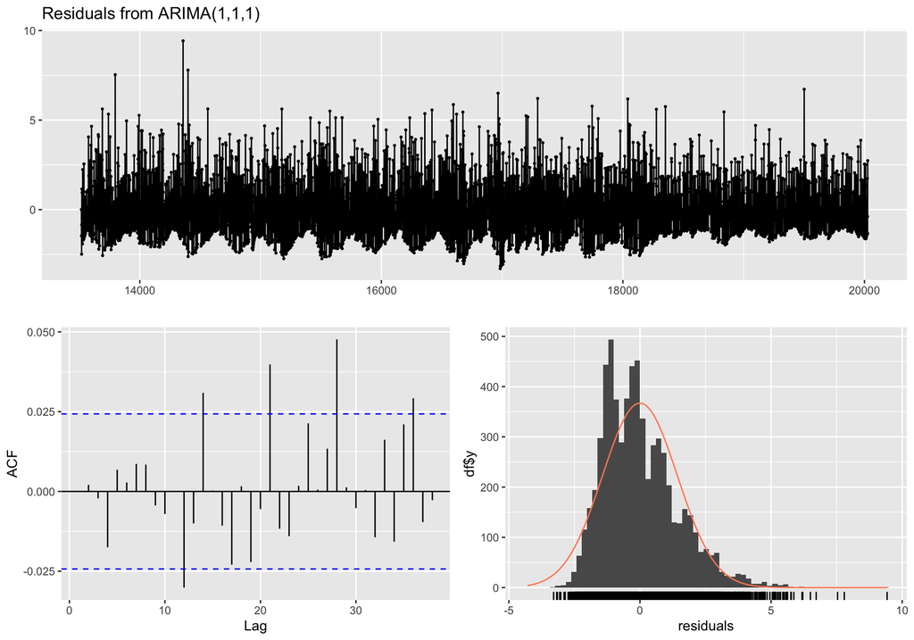

```
##
##  Ljung-Box test
##
## data:  Residuals from ARIMA(1,1,1)
## Q* = 3.8086, df = 8, p-value = 0.874
##
## Model df: 2.   Total lags used: 10
```

```r
checkresiduals(arima.calls)
```

Build a sample forecast for 11/1-11/7:

```r
forecast.7days <- forecast(arima.calls, h=7)
round(sum(forecast.7days$upper[,2]),0)
```

```
## [1] 29
```

```r
forecast.7days$mean
```

```
## Time Series:
## Start = 20028
## End = 20034
## Frequency = 1
## [1] 1.448065 1.396906 1.395881 1.395860 1.395860 1.395860 1.395860
```

Identify our forecast window:

```r
forecast.window <- as.numeric(as.Date("2025-12-31")-max(calls$DATE))
```

Forecast 2025

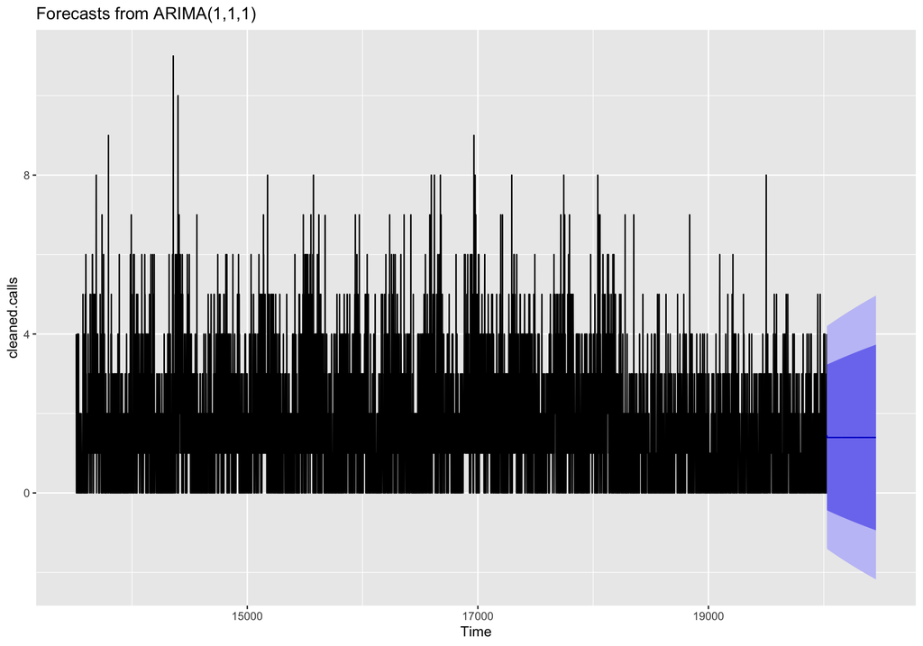

```r
forecast.2025 <- forecast(arima.calls, h=forecast.window)
autoplot(forecast.2025)
```